# Titanic Survival Analysis

Hinan Bilal

The Titanic sank on April 15th 1912 during her maiden voyage. This report analyzes the Titanic data for 1309 passengers and crews to determine how passengers’ survival depended on other measured variables in the dataset.

Loading the required libraries

```r
library(PASWR2)
```

```r
library(ggplot2)
library(dplyr)
library(GGally)
library(rpart)
library(rpart.plot)
```

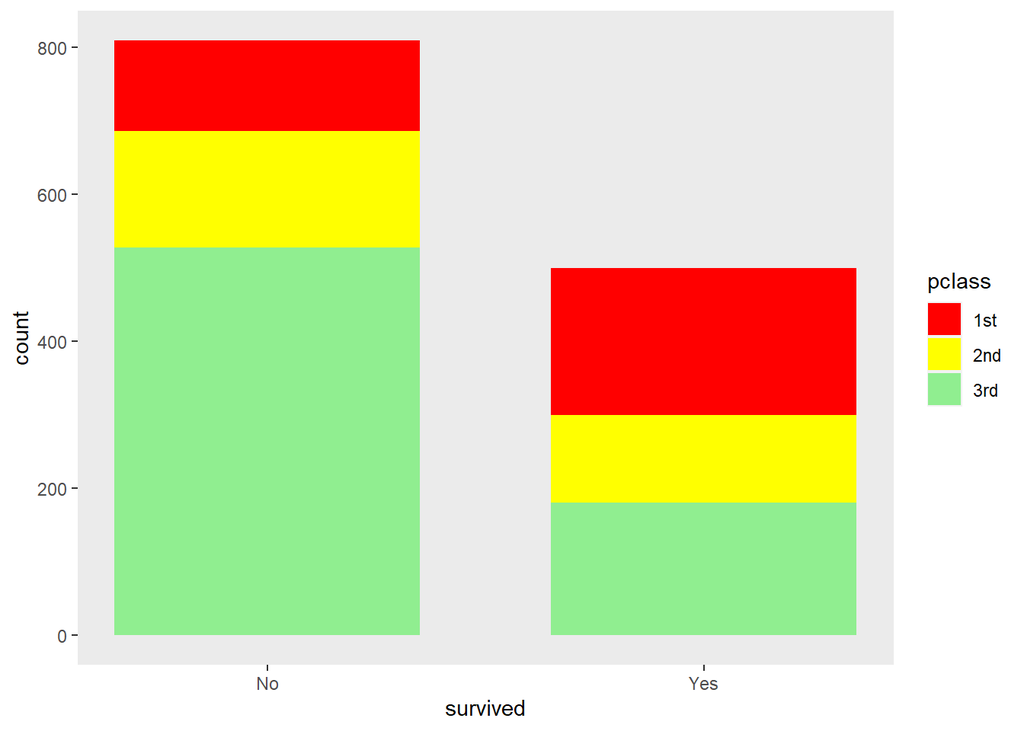

```r
ggplot(TITANIC3, aes(x=survived, fill=pclass)) +
  geom_bar(width=0.7) +
  scale_fill_manual(values=c("red", "yellow", "light green"))+
  theme(panel.grid.minor=element_blank(),panel.grid.major=element_blank())+
  scale_x_continuous(breaks = c(0,1), labels = c("No", "Yes"))
```

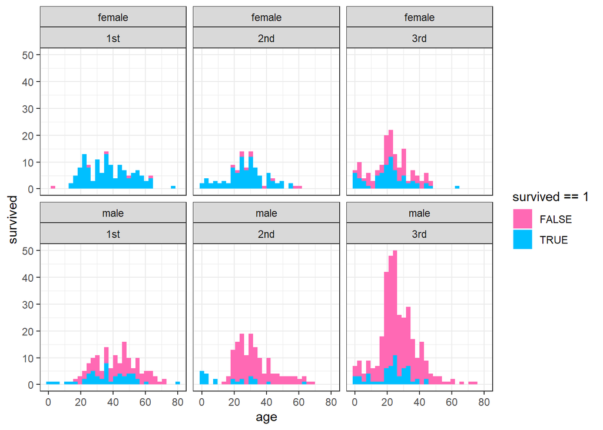

```r
#b

ggplot(TITANIC3, aes(x=age, fill=survived==1)) + theme_bw()+
  facet_wrap(sex~pclass)+geom_histogram(bnwidth=10)+scale_fill_manual(values=c("hotpink", "deepskyblue"))+labs(y="survived", x="age")
```

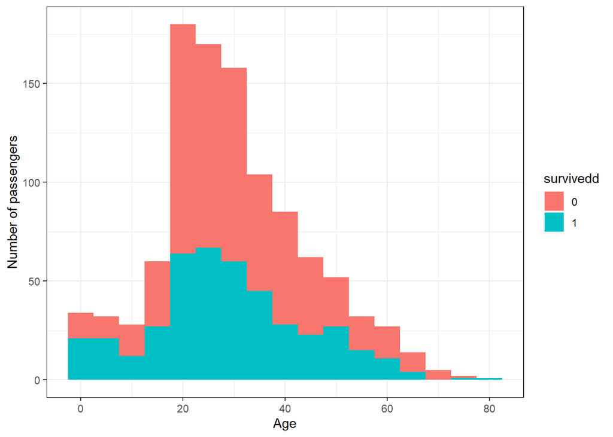

```r
survivedd<-as.factor(TITANIC3$survived)
agee<-as.factor(TITANIC3$age)

ggplot(TITANIC3, aes(x=age, fill=survivedd))+
  theme_bw()+
  geom_histogram(binwidth=5)+
  labs(y="Number of passengers", x="Age")
```

In the question d. We analysed that the women who survived had mean and median age greater then the women who died. This means a greater propotion of older women survived.

```r
#d
#mean of who survived
data<-TITANIC3[TITANIC3$sex=='female',]
da <- data[data$survived==1,]

ompleterecords <- na.omit(da$age)
print(mean(ompleterecords))
```

```
## [1] 29.81535
```

```r
print(median(ompleterecords))
```

```
## [1] 28.5
```

```r
#mean of who  didnt survived
data<-TITANIC3[TITANIC3$sex=='female',]
da <- data[data$survived==0,]

ompleterecords <- na.omit(da$age)
print(mean(ompleterecords))
```

```
## [1] 25.25521
```

```r
print(median(ompleterecords))
```

```
## [1] 24.5
```

In the question e. We analysed that the men who survived had lesser mean and median age then the men who died. This means a greater propotion of young males survived the incident.

```r
#e
#mean of who survived
data<-TITANIC3[TITANIC3$sex=='male',]
da <- data[data$survived==1,]

ompleterecords <- na.omit(da$age)
print(mean(ompleterecords))
```

```
## [1] 26.97778
```

```r
print(median(ompleterecords))
```

```
## [1] 27
```

```r
#mean of who  didnt survived
data<-TITANIC3[TITANIC3$sex=='male',]
da <- data[data$survived==0,]

ompleterecords <- na.omit(da$age)
print(mean(ompleterecords))
```

```
## [1] 31.51641
```

```r
print(median(ompleterecords))
```

```
## [1] 29
```

```r
#f
data2 <- TITANIC3[TITANIC3$pclass=='1st',]

daa <- data2[data2$survived==1,]

dat<-daa[daa$sex=='female',]
ompleterecords <- na.omit(dat$age)
print(paste("Age of youngest female survivor in first class",min(ompleterecords)))
```

```
## [1] "Age of youngest female survivor in first class 14"
```

In the question g. We have to conclude our observations from the data analysis. The plot of question a clearly shows the class warfare because too many 3rd class cabin people died. Furthermore, a greater propotion of 1st class passengers also survived. This shows elite passengers were given preference during the rescue mission. On the other side, we have also observed the male chivalry in the incident. In the 3rd class cabin where passenger fatality rate was high. Women survival rate was very much higher then the male survival rate. Same goes for all other cabins. This also means class warfare could not beat male chivalry because from graphs it seems like women were given priority for rescue in all three cabins.